# Session 4

# visualize scenarios as 5-year ages

How do these scenarios look after grouping to 5-year age intervals? Most of them no so bad. h3 reallt stands out, though. We can’t see this well when looking at the awful single age data, so this step really does help judge which method is best suited.

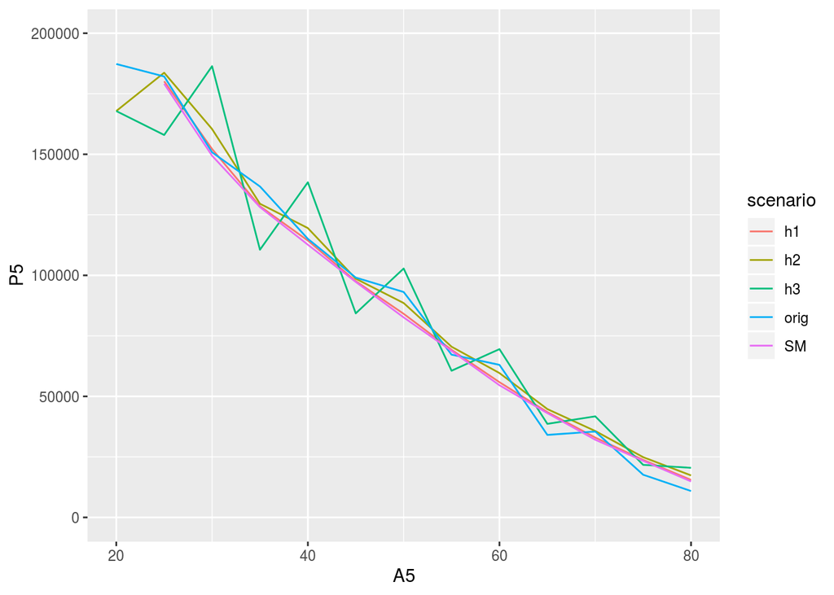

```r
Scenarios %>%
  group_by(scenario) %>%
  mutate(A5 = calcAgeAbr(Age)) %>%
  ungroup() %>%
  group_by(scenario, A5) %>%
  summarize(P5 = sum(Pop)) %>%
  ungroup() %>%
  ggplot(mapping = aes(x = A5,
                       y = P5,
                       color = scenario)) +
  geom_line() +
  xlim(20,80) +
  ylim(0, 2e5)
```

```r
KKN_test <-
  Scenarios %>%
  group_by(scenario) %>%
  mutate(A5 = Age - Age %% 5) %>%
  ungroup() %>%
  group_by(scenario, A5) %>%
  summarize(P5 = sum(Pop)) %>%
  ungroup() %>%
  group_by(scenario) %>%
  mutate(KKN = agesmth(P5, Age = A5, method = "kkn"))
```

## abridged lifetable function

This was taken from the help file for `LTabr()`. It reproduces a PAS spreadsheet. There are many other options to control how it gets done.

```r
#?LTabr
Exposures <- c(100958,466275,624134,559559,446736,370653,301862,249409,247473,223014,172260,149338,127242,105715,79614,53660,
        31021,16805,8000,4000,2000,1000)
Deaths <- c(8674,1592,618,411,755,1098,1100,1357,1335,3257,2200,4023,2167,4578,2956,4212,2887,2351,1500,900,500,300)

Age    <- c(0, 1, seq(5, 100, by = 5))
AgeInt <- c(diff(Age), NA)

PASLT <- LTabr(
    Deaths = Deaths,
        Exposures = Exposures,
        Age = Age,
        AgeInt = AgeInt,
        axmethod = "pas",
        IMR = .1,
        region = "n",
        Sex = "m")
```

## using demotools in custom utility functions

You can make a helper function to calculate the lifetable but return only one column (more in keeping with the lightweight vector-output preference in the package)

```r
LTcolumn <- function(column = "ex", ...){
  LTabr(...)[,column]
}
```

# How to file a bug report (live)

We give it a whirl, trying out some of the extrapolation methods. Interestingly this one gives unexpected output:`NaN` in the open age group for $a(x)$ and $e(x)$

```r
# This seems to have induced a bug, so we saw how to file a usable bug report.
LTabr(
    Deaths = Deaths[1:17],
        Exposures = Exposures[1:17],
        Age = Age[1:17],
        AgeInt = AgeInt[1:17],
        OAG = FALSE,
        OAnew = 110,
        extrapLaw = "gompertz",
        extrapFrom = 75,
        extrapFit = seq(40, 75, by = 5),
    )
```

```
##     Age AgeInt            nMx         nAx           nqx             lx
## 0     0      1 0.085916915945 0.275027596 0.08087916368 100000.0000000
## 1     1      4 0.003414294140 1.409311080 0.01353743290  91912.0836319
## 5     5      5 0.000990171982 2.500000000 0.00493863467  90667.8299669
## 10   10      5 0.000734506996 2.500000000 0.00366580358  90220.0546786
## 15   15      5 0.001690036173 2.500000000 0.00841462830  89889.3256789
## 20   20      5 0.002962339439 2.500000000 0.01470281041  89132.9404150
## 25   25      5 0.003644049268 2.500000000 0.01805575618  87822.4356912
## 30   30      5 0.005440862198 2.500000000 0.02683923948  86236.7352056
## 35   35      5 0.005394527888 2.500000000 0.02661371833  83922.2068173
## 40   40      5 0.014604464294 2.500000000 0.07045010631  81688.7248438
## 45   45      5 0.012771392082 2.500000000 0.06188118812  75933.7454940
## 50   50      5 0.026938890303 2.500000000 0.12619553250  71234.8751045
## 55   55      5 0.017030540230 2.500000000 0.08167526638  62245.3521084
## 60   60      5 0.043305112803 2.500000000 0.19537384773  57161.4463942
```

[output cut: 35 more lines]